# LAB 1

Joshua Lee

2021-02-01

# Tasks

## Task 1

1. Obtain the working directory.

```r
getwd()
```

```
## [1] "C:/Users/joshu_g4opbv7/Documents/MATH4753Lee0266/RPACKAGES/MATH4753LEE/Labs/Lab 1"
```

## Task 2

1. Read in the DDT file

```r
ddt <- read.csv("DDT.csv")
head(ddt)
```

```
##   RIVER MILE  SPECIES LENGTH WEIGHT DDT
## 1   FCM    5 CCATFISH   42.5    732  10
## 2   FCM    5 CCATFISH   44.0    795  16
## 3   FCM    5 CCATFISH   41.5    547  23
## 4   FCM    5 CCATFISH   39.0    465  21
## 5   FCM    5 CCATFISH   50.5   1252  50
## 6   FCM    5 CCATFISH   52.0   1255 150
```

## Task 3

```r
species <- ddt$SPECIES
print(species)
```

```
##   [1] "CCATFISH"  "CCATFISH"  "CCATFISH"  "CCATFISH"  "CCATFISH"  "CCATFISH"
##   [7] "CCATFISH"  "CCATFISH"  "CCATFISH"  "CCATFISH"  "CCATFISH"  "CCATFISH"
##  [13] "CCATFISH"  "CCATFISH"  "CCATFISH"  "CCATFISH"  "CCATFISH"  "CCATFISH"
##  [19] "CCATFISH"  "CCATFISH"  "CCATFISH"  "CCATFISH"  "CCATFISH"  "CCATFISH"
##  [25] "CCATFISH"  "CCATFISH"  "CCATFISH"  "CCATFISH"  "CCATFISH"  "CCATFISH"
##  [31] "SMBUFFALO" "SMBUFFALO" "SMBUFFALO" "SMBUFFALO" "SMBUFFALO" "SMBUFFALO"
##  [37] "CCATFISH"  "CCATFISH"  "CCATFISH"  "CCATFISH"  "CCATFISH"  "CCATFISH"
##  [43] "LMBASS"    "LMBASS"    "LMBASS"    "LMBASS"    "LMBASS"    "LMBASS"
##  [49] "CCATFISH"  "CCATFISH"  "CCATFISH"  "CCATFISH"  "CCATFISH"  "CCATFISH"
##  [55] "SMBUFFALO" "SMBUFFALO" "SMBUFFALO" "SMBUFFALO" "SMBUFFALO" "SMBUFFALO"
##  [61] "CCATFISH"  "CCATFISH"  "CCATFISH"  "CCATFISH"  "CCATFISH"  "CCATFISH"
##  [67] "CCATFISH"  "CCATFISH"  "CCATFISH"  "CCATFISH"  "CCATFISH"  "CCATFISH"
##  [73] "SMBUFFALO" "SMBUFFALO" "SMBUFFALO" "SMBUFFALO" "SMBUFFALO" "SMBUFFALO"
##  [79] "CCATFISH"  "CCATFISH"  "CCATFISH"  "CCATFISH"  "CCATFISH"  "CCATFISH"
##  [85] "CCATFISH"  "CCATFISH"  "CCATFISH"  "CCATFISH"  "CCATFISH"  "CCATFISH"
##  [91] "SMBUFFALO" "SMBUFFALO" "SMBUFFALO" "SMBUFFALO" "SMBUFFALO" "SMBUFFALO"
##  [97] "CCATFISH"  "CCATFISH"  "CCATFISH"  "CCATFISH"  "CCATFISH"  "CCATFISH"
## [103] "CCATFISH"  "CCATFISH"  "CCATFISH"  "CCATFISH"  "CCATFISH"  "CCATFISH"
## [109] "SMBUFFALO" "SMBUFFALO" "SMBUFFALO" "SMBUFFALO" "SMBUFFALO" "SMBUFFALO"
## [115] "CCATFISH"  "CCATFISH"  "CCATFISH"  "CCATFISH"  "CCATFISH"  "CCATFISH"
## [121] "CCATFISH"  "CCATFISH"  "CCATFISH"  "CCATFISH"  "CCATFISH"  "CCATFISH"
## [127] "SMBUFFALO" "SMBUFFALO" "CCATFISH"  "CCATFISH"  "CCATFISH"  "CCATFISH"
## [133] "CCATFISH"  "CCATFISH"  "SMBUFFALO" "SMBUFFALO" "SMBUFFALO" "SMBUFFALO"
## [139] "LMBASS"    "LMBASS"    "LMBASS"    "LMBASS"    "LMBASS"    "LMBASS"
```

3. There are 3 different SPECIES in the ddt data set.
4. Subset the ddt data set so that we see only the observations with SPECIES, LMBASS and WEIGHT bigger than 800gms

```r
with(ddt, ddt[SPECIES == "LMBASS" & WEIGHT > 800,])
```

```
##     RIVER MILE SPECIES LENGTH WEIGHT DDT
## 141   TRM  345  LMBASS     30    856 2.2
## 144   TRM  345  LMBASS     36   1433 1.9
```

5. Subset the ddt data set so that we see only those observations where the RIVER is SCM and DDT bigger than 4.0

```r
with(ddt, ddt[RIVER == "SCM" & DDT > 4.0,])
```

```
##    RIVER MILE  SPECIES LENGTH WEIGHT DDT
## 16   SCM    1 CCATFISH     45    984 9.1
## 17   SCM    1 CCATFISH     43    965 7.8
## 18   SCM    1 CCATFISH     45   1084 4.1
```

CLICKER QUESTIONS

1. Find the mean length of fish in the ddt data frame.

```r
l = ddt$LENGTH
mean(l)
```

```
## [1] 42.8125
```

2. What is the standard deviation of the weight of fish in the ddt data frame?

```r
w = ddt$WEIGHT
sd(w)
```

```
## [1] 376.5461
```

3. Is this the plot of LENGTH vs WEIGHT from the ddt data frame?

   A: Yes

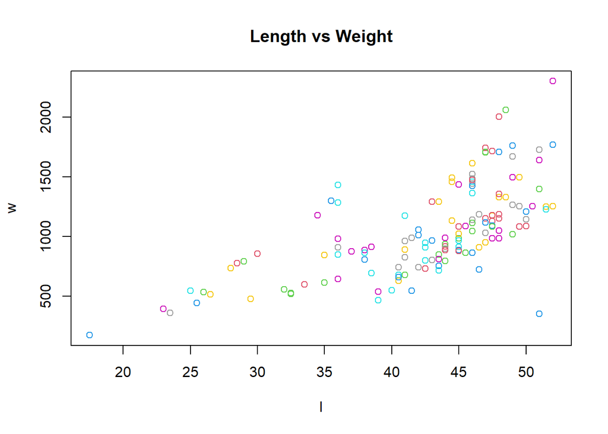

```r
plot(l, w, col = 10:16, main = "Length vs Weight")
```

4. If v=1:20 what is the last value of v/20?

   A: Since the last value of v is 20, then v/20 would equal 1

## Task 4

1). Make a table of the rivers.

```r
riv = ddt$RIVER
table(riv)
```

```
## riv
## FCM LCM SCM TRM
##   6   6   6 126
```

2. Make a color coded barplot of the rivers.

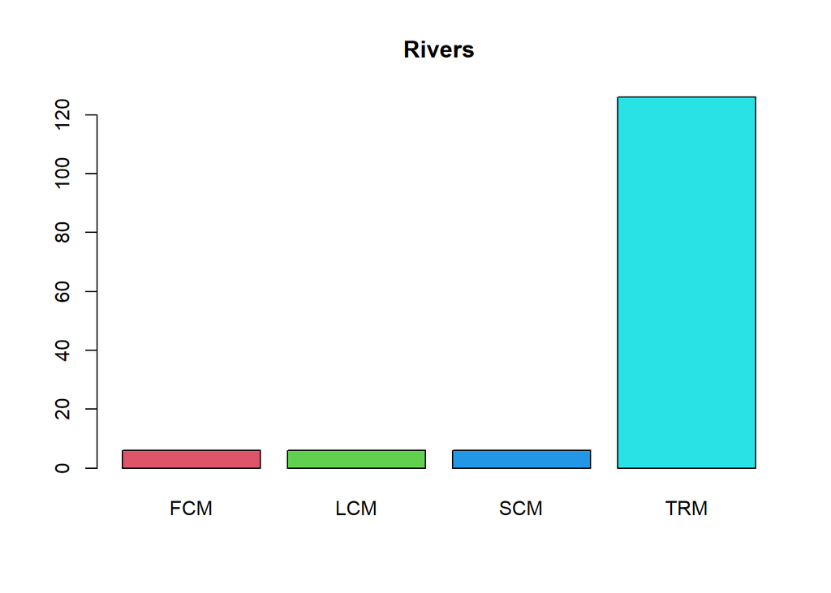

```r
tableR = table(riv)
barplot(tableR, col = 10:16, main = "Rivers")
```

3. Make a table of the rivers crossed with the species of fish.

```r
table(riv, species)
```

```
##      species
## riv   CCATFISH LMBASS SMBUFFALO
##   FCM        6      0         0
##   LCM        6      0         0
##   SCM        6      0         0
##   TRM       78     12        36
```

4. Make a barplot of the rivers crossed with the species of fish.

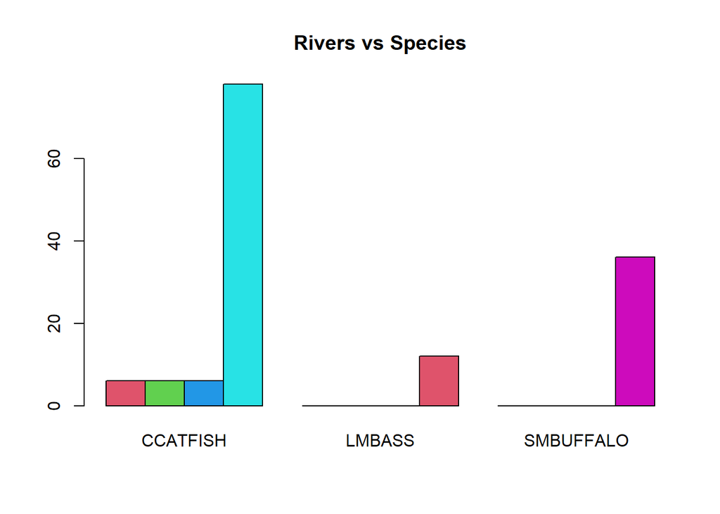

```r
tableRxS = table(riv, species)
barplot(tableRxS, beside = TRUE, col = 10:16, main = "Rivers vs Species")
```

## Task 5

1. Make a pie chart of Fish SPECIES

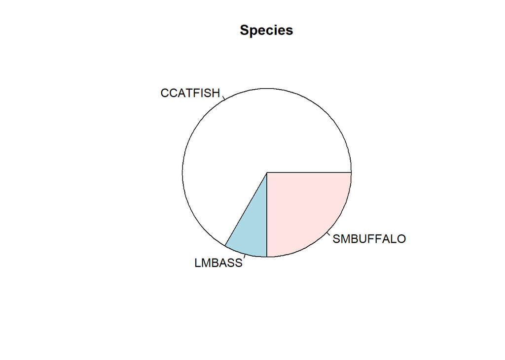

```r
pie(table(species), main = "Species")
```

2) Make a pie chart of RIVERS

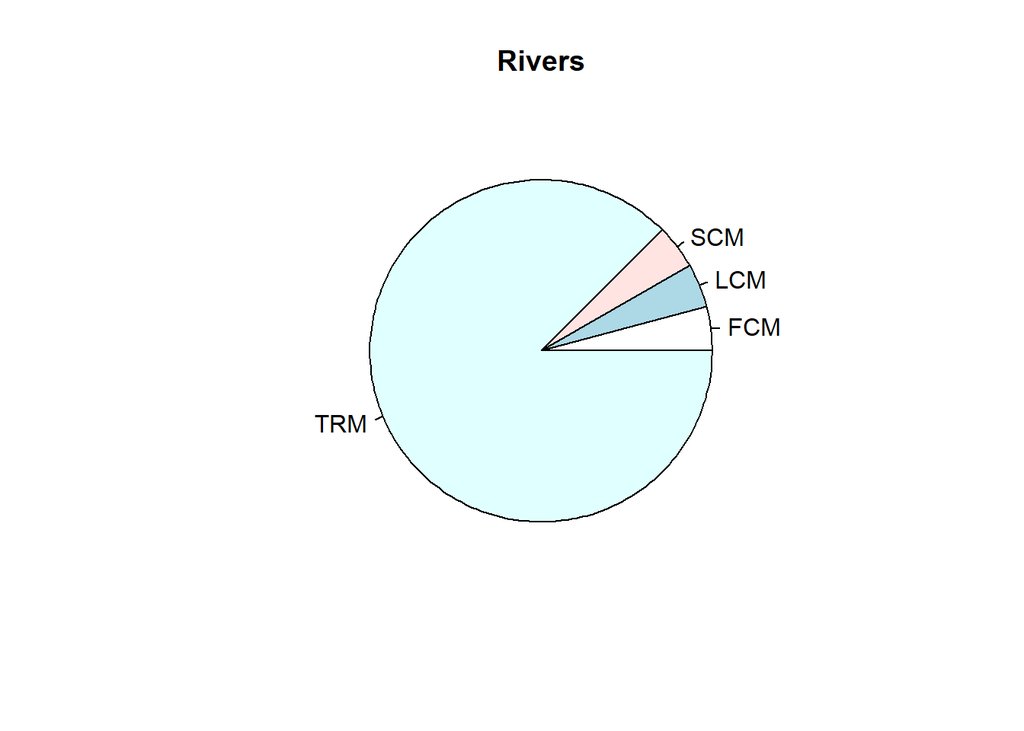

```r
pie(table(riv), main = "Rivers")
```

## Task 6

1. Make a boxplot of the variable DDT (I cut off two points)

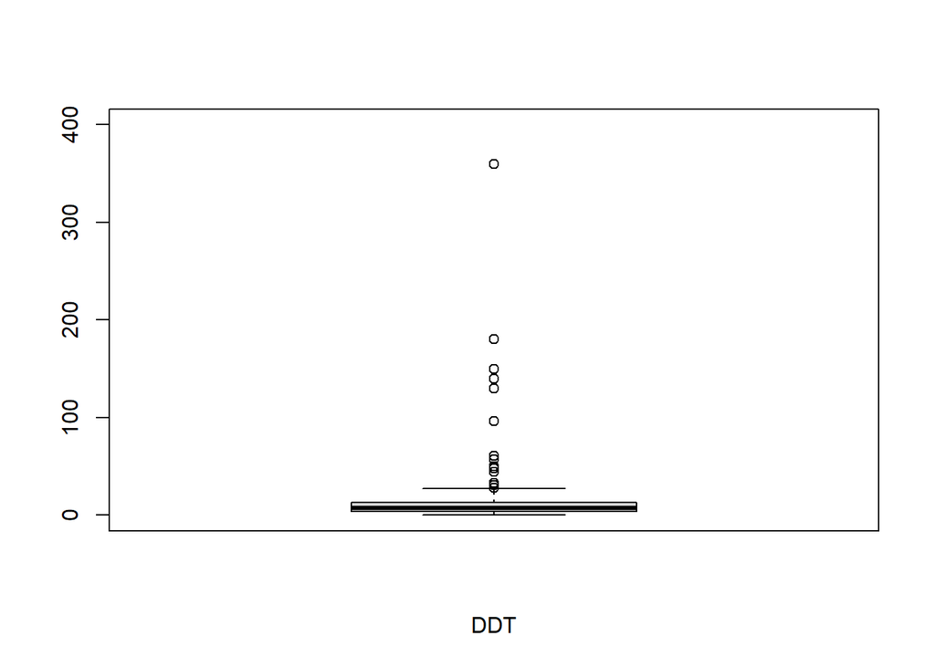

```r
boxplot(ddt$DDT, xlab = "DDT", ylim = c(0, 400))
```

2) Make a boxplot of the variable WEIGHT

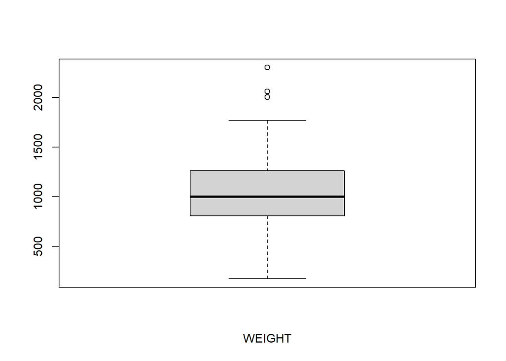

```r
boxplot(w, xlab = "WEIGHT")
```

3) Make a boxplot of the variable LENGTH

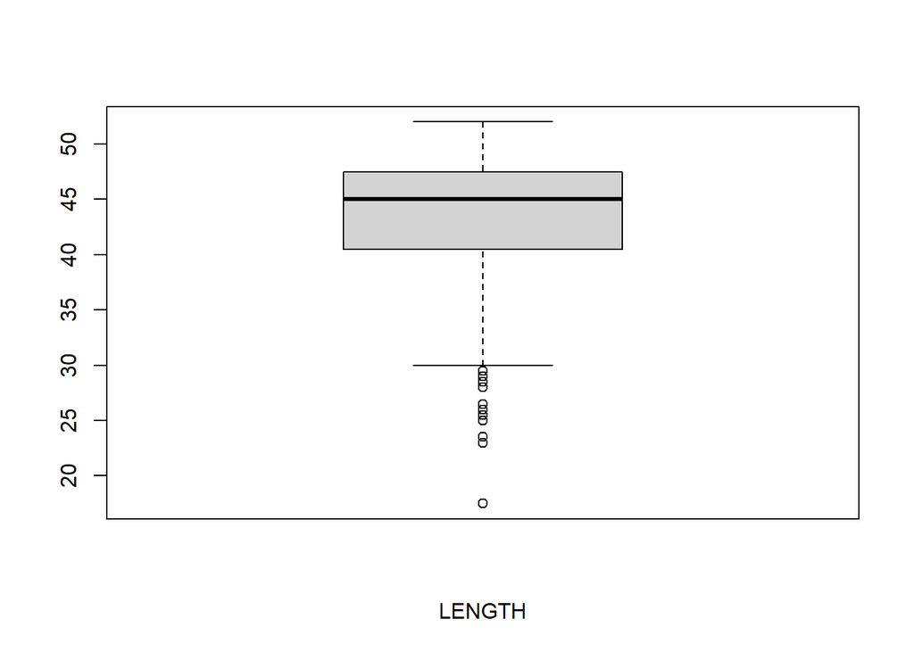

```r
boxplot(l, xlab = "LENGTH")
```

## Task 7

1. Make a coplot LENGTH vs WEIGHT given RIVER

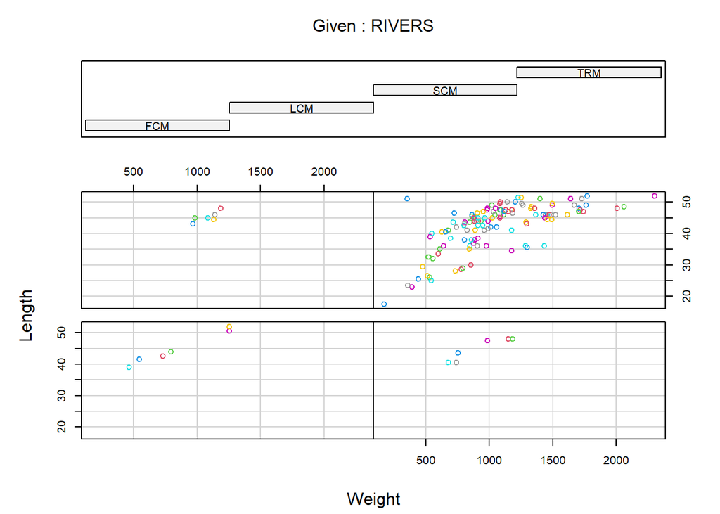

```r
RIVERS = ddt$RIVER
coplot(l~w | RIVERS, col = 10:16, xlab = "Weight", ylab = "Length")
```

## Task 8

Creating the 3 plots with ggplot

1. Boxplot

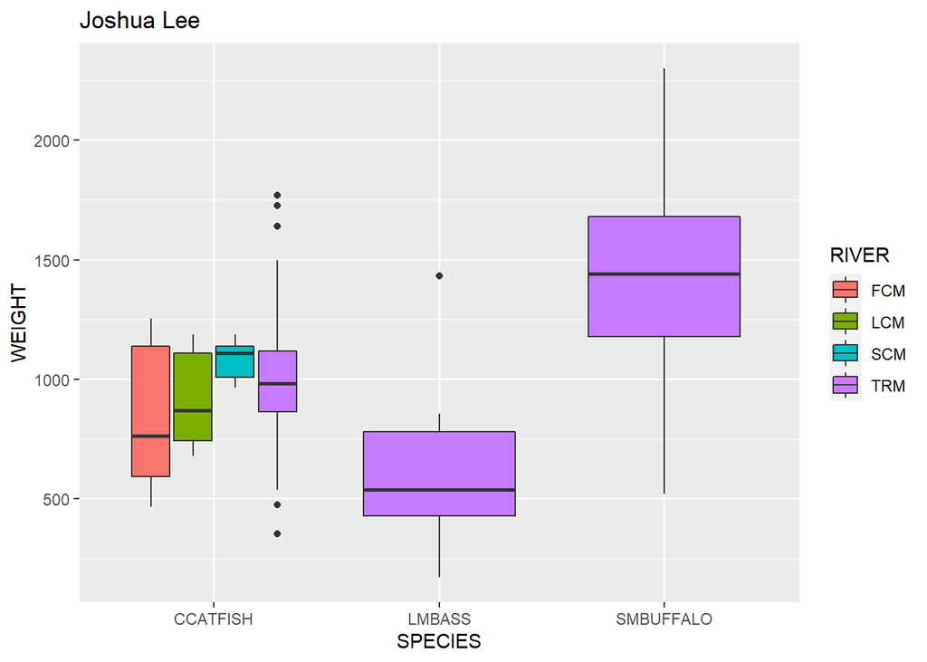

```r
library(ggplot2)
box1 = ggplot(data = ddt, aes(x = SPECIES, y = WEIGHT))
box1 = box1 + geom_boxplot(aes(fill = RIVER)) + labs(title = "Joshua Lee")
box1
```

2. Violin Plot

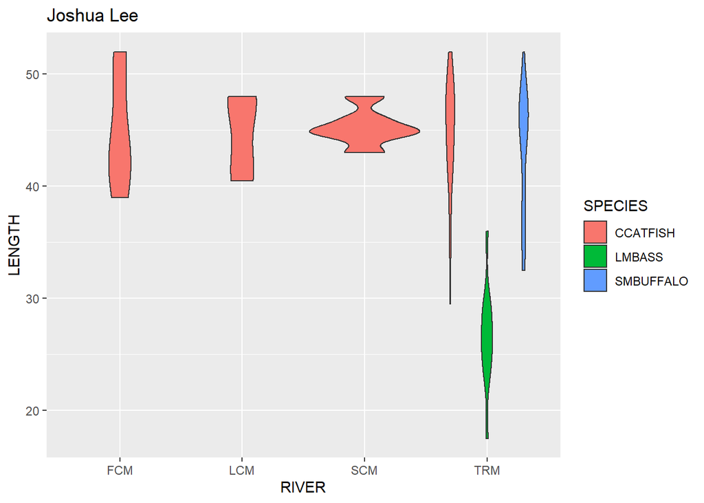

```r
violin1 = ggplot(data = ddt, aes(x = RIVER, y = LENGTH))
violin1 = violin1 + geom_violin(aes(fill = SPECIES)) + labs(title = "Joshua Lee")
violin1
```

3. Scatter plot

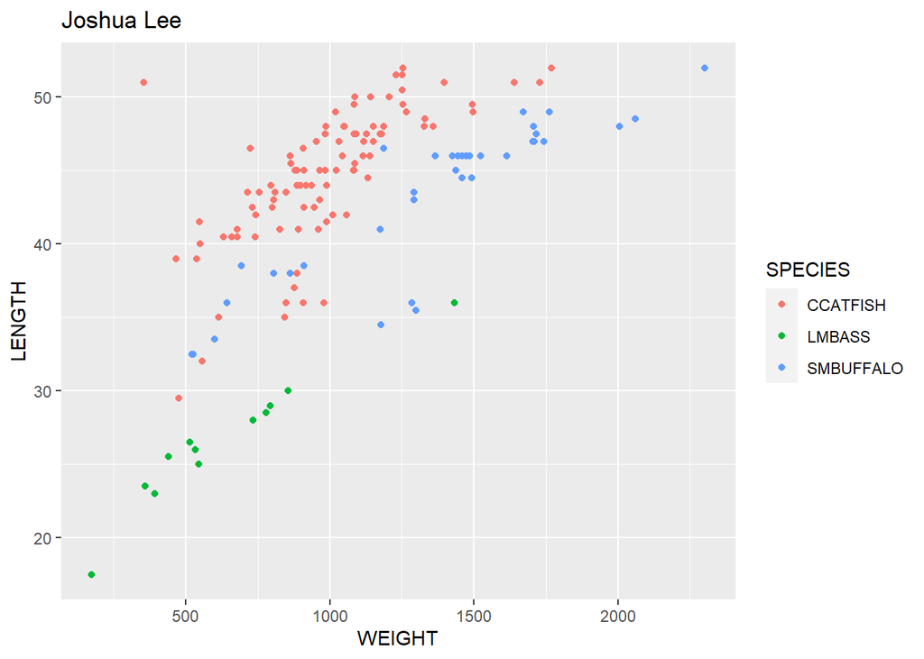

```r
scatter1 = ggplot(data = ddt, aes(x = WEIGHT, y = LENGTH), aes(fill = SPECIES))
scatter1 = scatter1 + geom_point(aes(colour = SPECIES)) + labs(title = "Joshua Lee")
scatter1
```